# Portugal Tourism Forecast

Group Project

30 Oct 2025

## Introduction

Tourism in Portugal is a major economic driver. This makes it an excellent data-set for a forecasting case study. According to OECD Tourism Papers 2025/10, travel and tourism made up nearly half of Portugal’s service exports and directly contributed about 9.7% of national GDP in 2024. This industry also recorded 80.3 million overnight stays in 2024, which is a 4.8% increase from the previous year. Stakeholders at all levels need projections of visitor volumes to make well-informed choices. The monthly Portuguese tourism data-set from Euro Stat (www.eurostat.com) is particularly ideal in this case. It is an official, high-quality time series that provides timely insights into travel demand trends and offering extensive historical data. Monthly data-set is a good choice because it captures clear fluctuations and seasonal patterns that might otherwise be missed in less frequent data. Portugal’s tourism demand shows a clear seasonal trend. These regular highs and lows make the series ideal for Seasonal ARIMA (SARIMA) modeling. The SARIMA framework is well-suited to capture periodic seasonality along with overall trends. Forecasting monthly tourism volumes in Portugal can provide significant policy, economic, and operational benefits. Government agencies and tourism authorities can predict demand spikes or declines, allowing for better resource allocation and infrastructure planning, such as preparing transportation networks and public services for busy tourist seasons. Businesses in the travel and hospitality sector rely on these forecasts for staffing and inventory management. This ensures they have enough employees, hotel rooms, flights, and other services available to meet expected demand. Summarily, accurate tourism demand forecasts help stakeholders optimize operations and budgets, prevent overcrowding during peak times, and create sustainable tourism policies.

### Installation of all required packages

```r
library("fpp3")
library("kableExtra")
library("tsibble")
```

### Loading the data and dealing with the missing values

```r
library(readr)
pt_tourism_dataset <- read_csv("pt_tourism.csv")
pt_tourism_dataset <- pt_tourism_dataset[complete.cases(pt_tourism_dataset),]
```

### Renaming the key columns

```r
colnames(pt_tourism_dataset) <- c("month", "tourist")
print(pt_tourism_dataset)
```

```
## # A tibble: 204 × 2
##    month   tourist
##    <chr>     <dbl>
##  1 2008-01  280769
##  2 2008-02  368044
##  3 2008-03  548608
##  4 2008-04  592216
##  5 2008-05  741789
##  6 2008-06  665289
##  7 2008-07  805355
##  8 2008-08  959778
##  9 2008-09  782664
## 10 2008-10  612167
## # ℹ 194 more rows
```

### Convert to a time indexed table

```r
pt_tour_ts <- pt_tourism_dataset  %>%
  mutate(month = yearmonth(month)) %>%
  as_tsibble(index = month)
print(pt_tour_ts)
```

```
## # A tsibble: 204 x 2 [1M]
##       month tourist
##       <mth>   <dbl>
##  1 2008 Jan  280769
##  2 2008 Feb  368044
##  3 2008 Mar  548608
##  4 2008 Apr  592216
##  5 2008 May  741789
##  6 2008 Jun  665289
##  7 2008 Jul  805355
##  8 2008 Aug  959778
##  9 2008 Sep  782664
## 10 2008 Oct  612167
## # ℹ 194 more rows
```

### First Step: Visually assess the time series plot including the ACF and PACF to check if the process is stationary

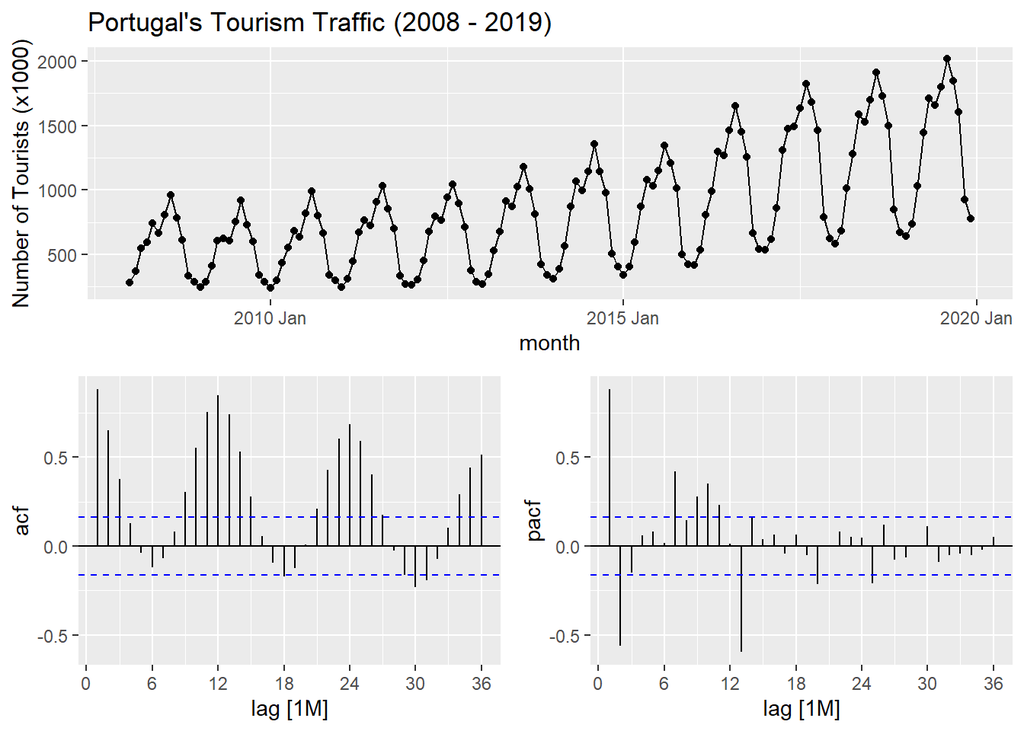

```r
pt_tour  <- pt_tour_ts  %>%
  filter(year(month) < 2020) %>%
  mutate(tourist = tourist / 1000) %>%
  select(month, tourist)
gg_tsdisplay(pt_tour, tourist, plot_type = 'partial', lag = 36) +
  labs(title = "Portugal's Tourism Traffic (2008 - 2019)", y = "Number of Tourists (x1000)")
```

### Plot Results interpretation:

After plotting the graph and analyzing the plots, including the ACF and the PACF, there was an evidence of seasonality and a nonlinear trend. There is also an evidence of variance fluctuation, so we will stabilize the plot with a Box-Transformation and compare the plots with the stabilized variance and the original plot to know if the stabilization was necessary.

### Stabilizing the variance using a Box–Cox transform.

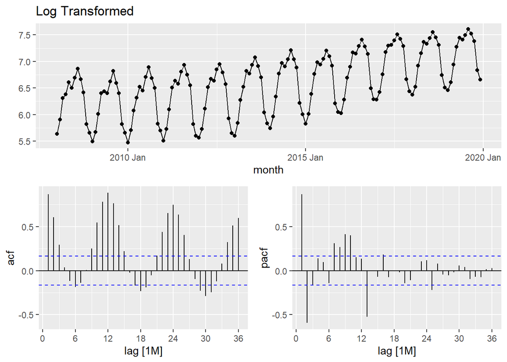

```r
library(dplyr)
library(feasts)
pt_tour %>%
  gg_tsdisplay(log(tourist), plot_type = "partial", lag = 36) + labs(title = "Log Transformed", y = "")
```

### Plot Results interpretation:

The variance appeared to be stabilized but yet there is no significant change in the appearance of the plot when compared to the original plot. Therefore, we conclude that the change is negligible and we maintain the original data-set and proceed with the next step - Seasonal Difference. But firstly, we also have to test for the presence of a Unit Root. We will be installing a library urca which is used for the Augmented Dickey Fuller Test (ADF) to test for the trend and apply the appropriate difference.

```r
library(urca)
summary(ur.df(pt_tour$tourist, type = "trend", lags = 24))
```

```
##
## ###############################################
## # Augmented Dickey-Fuller Test Unit Root Test #
## ###############################################
##
## Test regression trend
##
##
## Call:
## lm(formula = z.diff ~ z.lag.1 + 1 + tt + z.diff.lag)
##
## Residuals:
##     Min      1Q  Median      3Q     Max
## -93.214 -21.211  -1.437  19.836 168.458
##
## Coefficients:
##              Estimate Std. Error t value Pr(>|t|)
## (Intercept)  25.27553   17.75288   1.424 0.157904
## z.lag.1      -0.11219    0.06195  -1.811 0.073410 .
## tt            1.08629    0.48652   2.233 0.027990 *
## z.diff.lag1  -0.37083    0.10524  -3.524 0.000665 ***
## z.diff.lag2  -0.15830    0.10981  -1.442 0.152818
## z.diff.lag3  -0.07528    0.11075  -0.680 0.498394
## z.diff.lag4  -0.04566    0.11110  -0.411 0.682011
## z.diff.lag5  -0.03812    0.11086  -0.344 0.731714
## z.diff.lag6  -0.03020    0.11157  -0.271 0.787220
## z.diff.lag7  -0.24490    0.11096  -2.207 0.029796 *
## z.diff.lag8  -0.18627    0.11267  -1.653 0.101697
## z.diff.lag9  -0.15734    0.11117  -1.415 0.160336
## z.diff.lag10 -0.17316    0.11112  -1.558 0.122605
## z.diff.lag11 -0.03540    0.11225  -0.315 0.753224
## z.diff.lag12  0.42671    0.10877   3.923 0.000168 ***
## z.diff.lag13  0.26238    0.11371   2.307 0.023274 *
## z.diff.lag14  0.04335    0.11938   0.363 0.717345
## z.diff.lag15 -0.11187    0.11618  -0.963 0.338103
## z.diff.lag16 -0.17341    0.11389  -1.523 0.131276
## z.diff.lag17 -0.13533    0.11233  -1.205 0.231374
## z.diff.lag18 -0.20540    0.10955  -1.875 0.063961 .
## z.diff.lag19  0.02692    0.11157   0.241 0.809865
## z.diff.lag20 -0.01927    0.11134  -0.173 0.862999
## z.diff.lag21 -0.06455    0.11213  -0.576 0.566280
## z.diff.lag22 -0.08539    0.11171  -0.764 0.446604
## z.diff.lag23 -0.21952    0.10937  -2.007 0.047675 *
## z.diff.lag24  0.34981    0.09873   3.543 0.000624 ***
## ---
## Signif. codes:  0 '***' 0.001 '**' 0.01 '*' 0.05 '.' 0.1 ' ' 1
##
## Residual standard error: 40.25 on 92 degrees of freedom
## Multiple R-squared:  0.9748, Adjusted R-squared:  0.9677
## F-statistic:   137 on 26 and 92 DF,  p-value: < 2.2e-16
##
##
## Value of test-statistic is: -1.811 3.0876 2.9203
##
## Critical values for test statistics:
##       1pct  5pct 10pct
## tau3 -3.99 -3.43 -3.13
## phi2  6.22  4.75  4.07
## phi3  8.43  6.49  5.47
```

### Interpreting the result for the ADF test

We start from a high lag and descend to get the phi1 value of the last lag that falls below 10% significance. We started from lag 27 and settled at 24 lags which gave us a phi1 value of 0.000624 , which falls within the acceptable range of values. Using the GTS t-dig approach, the results of the ADF test showed the existence of a Unit Root, since ‘-1.811’ is not more negative than ‘−3.43’ (5% level), so we fail to reject the Null hypothesis. Thus we need at least one seasonal difference.

### Applying Seasonal differencing then re-checking stationarity.

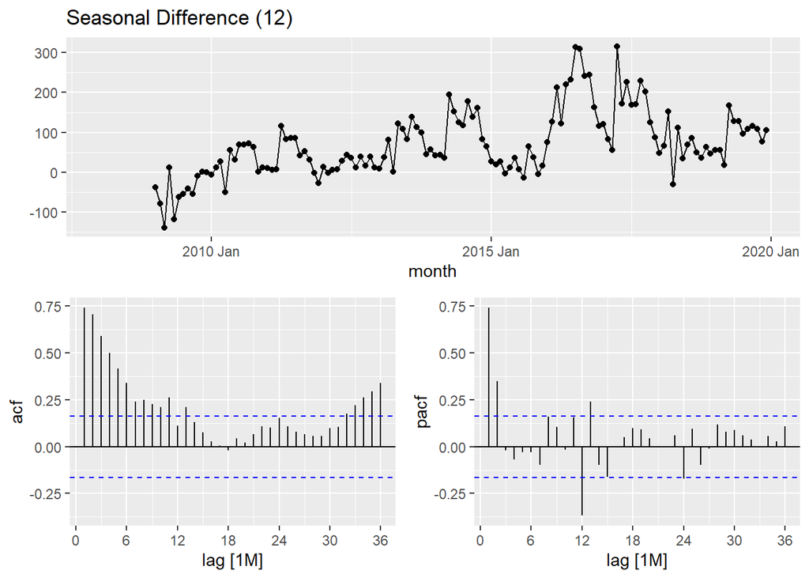

```r
pt_tour %>%
  gg_tsdisplay(difference(tourist, 12), plot_type = "partial", lag = 36) +
  labs(title = "Seasonal Difference (12)", y = "")
```

### Seasonal difference results interpretation:

After taking the seasonal difference, the plot was analyzed and it still exhibited patterns of constitutionality and so, further tests will be needed to check for the presence of a unit root.

### Unit root test with drift after applying: Seasonal Differencing

```r
pt_tour <- pt_tour %>%
  mutate(d12_tourist = difference(tourist, 12))
library(urca)
summary(ur.df(
  na.omit(pt_tour$d12_tourist),
  type = c('drift'),
  lags = 12
))
```

```
##
## ###############################################
## # Augmented Dickey-Fuller Test Unit Root Test #
## ###############################################
##
## Test regression drift
##
##
## Call:
## lm(formula = z.diff ~ z.lag.1 + 1 + z.diff.lag)
##
## Residuals:
##     Min      1Q  Median      3Q     Max
## -84.319 -27.335  -2.119  22.433 184.831
##
## Coefficients:
##              Estimate Std. Error t value Pr(>|t|)
## (Intercept)  14.61622    6.89119   2.121  0.03628 *
## z.lag.1      -0.16178    0.07337  -2.205  0.02965 *
## z.diff.lag1  -0.18465    0.10254  -1.801  0.07461 .
## z.diff.lag2   0.04460    0.10236   0.436  0.66395
## z.diff.lag3   0.06362    0.10106   0.630  0.53037
## z.diff.lag4   0.04441    0.09943   0.447  0.65605
## z.diff.lag5  -0.00833    0.09721  -0.086  0.93187
## z.diff.lag6  -0.02578    0.09238  -0.279  0.78074
## z.diff.lag7  -0.23514    0.09104  -2.583  0.01118 *
## z.diff.lag8  -0.10571    0.09268  -1.141  0.25663
## z.diff.lag9  -0.01055    0.09512  -0.111  0.91187
## z.diff.lag10  0.03105    0.09331   0.333  0.74000
## z.diff.lag11  0.25675    0.09304   2.760  0.00683 **
## z.diff.lag12 -0.29012    0.09018  -3.217  0.00172 **
## ---
## Signif. codes:  0 '***' 0.001 '**' 0.01 '*' 0.05 '.' 0.1 ' ' 1
##
## Residual standard error: 43.95 on 105 degrees of freedom
## Multiple R-squared:  0.484,  Adjusted R-squared:  0.4201
## F-statistic: 7.577 on 13 and 105 DF,  p-value: 2.36e-10
##
##
## Value of test-statistic is: -2.2048 2.5989
##
## Critical values for test statistics:
##       1pct  5pct 10pct
## tau2 -3.46 -2.88 -2.57
## phi1  6.52  4.63  3.81
```

### Applying Seasonal Differencing and First order Differencing

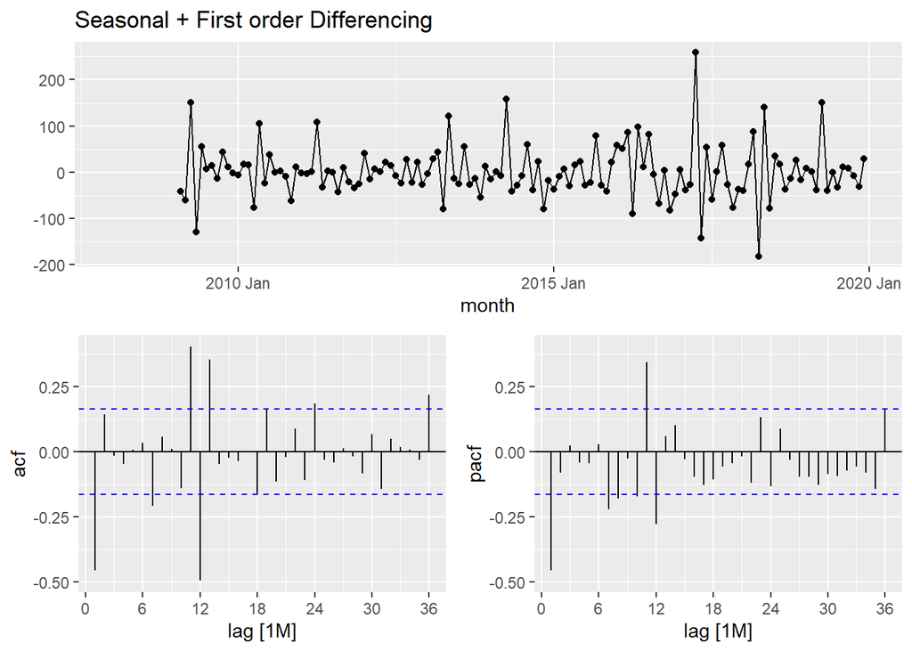

```r
pt_tour %>%
  gg_tsdisplay(difference(d12_tourist),
               plot_type = 'partial',
               lag = 36) +
  labs(title = "Seasonal + First order Differencing", y = "")
```

### First order difference report

After taking a further first order difference, the plot was analyzed and it exhibits a pattern of stationary. However, the decision is subject to a final ADF test to verify the absence of a unit root.

### Unit root test after applying: Seasonal Differencing + First Order Differencing

```r
pt_tour <- pt_tour %>%
  mutate(dd_tourist = difference(d12_tourist))
library(urca)
summary(ur.df(
  na.omit(pt_tour$dd_tourist),
  type = c('none'),
  lags = 11
))
```

```
##
## ###############################################
## # Augmented Dickey-Fuller Test Unit Root Test #
## ###############################################
##
## Test regression none
##
##
## Call:
## lm(formula = z.diff ~ z.lag.1 - 1 + z.diff.lag)
##
## Residuals:
##      Min       1Q   Median       3Q      Max
## -100.354  -25.579    1.356   24.213  172.572
##
## Coefficients:
##              Estimate Std. Error t value Pr(>|t|)
## z.lag.1      -2.18555    0.50690  -4.312 3.62e-05 ***
## z.diff.lag1   0.89455    0.48772   1.834 0.069413 .
## z.diff.lag2   0.84113    0.45168   1.862 0.065315 .
## z.diff.lag3   0.81308    0.41223   1.972 0.051145 .
## z.diff.lag4   0.77220    0.37162   2.078 0.040110 *
## z.diff.lag5   0.68354    0.33399   2.047 0.043153 *
## z.diff.lag6   0.58842    0.30429   1.934 0.055785 .
## z.diff.lag7   0.29275    0.27481   1.065 0.289137
## z.diff.lag8   0.14420    0.24268   0.594 0.553638
## z.diff.lag9   0.09527    0.20406   0.467 0.641561
## z.diff.lag10  0.09732    0.15521   0.627 0.532001
## z.diff.lag11  0.32612    0.08977   3.633 0.000432 ***
## ---
## Signif. codes:  0 '***' 0.001 '**' 0.01 '*' 0.05 '.' 0.1 ' ' 1
##
## Residual standard error: 44.6 on 107 degrees of freedom
## Multiple R-squared:  0.8104, Adjusted R-squared:  0.7892
## F-statistic: 38.12 on 12 and 107 DF,  p-value: < 2.2e-16
##
##
## Value of test-statistic is: -4.3116
##
## Critical values for test statistics:
##       1pct  5pct 10pct
## tau1 -2.58 -1.95 -1.62
```

### Interpreting the result for the ADF test

After analyzing the output of the ADF test, the ADF test statistic is τ = −4.3116 which is less than −1.95,and now we can reject the null hypothesis at the 5%. We proceed to model identification.

### Identification of the Mmdel through the assessment of the ACF and PACF

Based on the previous stationary plot, we will start with fitting several models. We will then estimate the models, compare and assess the information criteria. We would start with using the PACF to select the non-seasonal part of the model and the ACF to select the seasonal part of the model. In our process, we removed the long-run trend and yearly seasonality through first and seasonal difference (d=1, D=1).

Consequently, this initial analysis suggests that a possible model for these data is an ARIMA(1,1,0)(0,1,2). We fit this model, along with some variations on it and compute the AICc values.

```r
pt_fit <- pt_tour %>%
  model(
    sarima110_012 = ARIMA(tourist ~ pdq(1,1,0) + PDQ(0,1,2)),
    sarima111_012 = ARIMA(tourist ~ pdq(1,1,0) + PDQ(0,1,1)),
    sarima111_111 = ARIMA(tourist ~ pdq(1,1,1) + PDQ(1,1,1)),
    sarima110_112 = ARIMA(tourist ~ pdq(1,1,0) + PDQ(1,1,2)),
    sarima110_111 = ARIMA(tourist ~ pdq(1,1,0) + PDQ(1,1,1)),
    sarima111_112 = ARIMA(tourist ~ pdq(1,1,1) + PDQ(1,1,2))
  )


#checking the information criteria

glance(pt_fit) %>% arrange(AICc) %>% select(.model:BIC)
```

| .model | sigma2 | log_lik | AIC | AICc | BIC |
| --- | --- | --- | --- | --- | --- |
| sarima110_112 | 1819.095 | -682.8470 | 1375.694 | 1376.174 | 1390.070 |
| sarima111_112 | 1813.356 | -682.4760 | 1376.952 | 1377.629 | 1394.203 |
| sarima110_012 | 2016.639 | -685.9521 | 1379.904 | 1380.222 | 1391.405 |
| sarima110_111 | 2333.930 | -693.5714 | 1395.143 | 1395.460 | 1406.644 |
| sarima111_111 | 2346.857 | -693.4721 | 1396.944 | 1397.424 | 1411.320 |
| sarima111_012 | 2489.549 | -697.5285 | 1401.057 | 1401.246 | 1409.683 |

### Diagnostic check plot for residuals

From the analysis table of the estimated models, we select the model SARIMA(1,1,0)(1,1,2) according to the information criteria. Then we proceed to analyze the residuals.

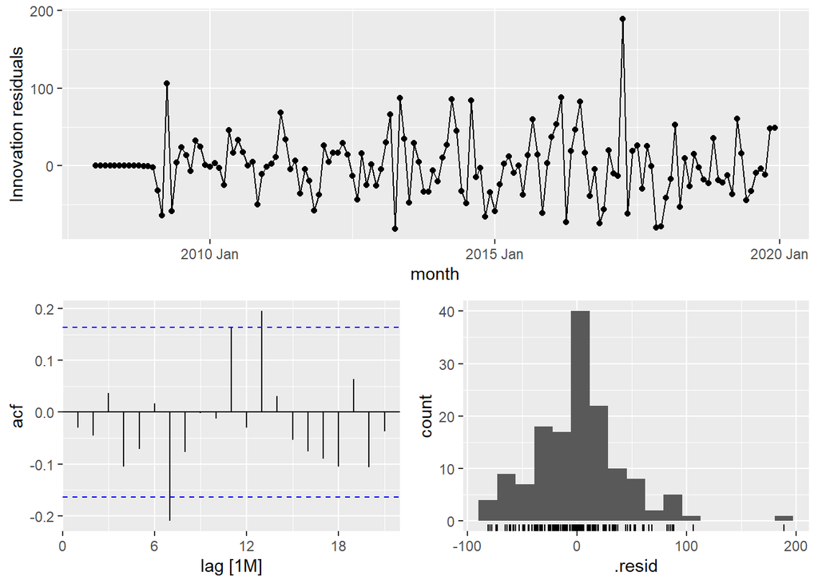

```r
pt_fit %>%
  select(sarima110_112) %>%
  gg_tsresiduals()
```

### Statistical Tests of the Residuals

```r
#Ljung-Box test:
augment(pt_fit) %>%
filter(.model=='sarima110_112') %>%
features(.innov, ljung_box, lag = 36)
```

| .model | lb_stat | lb_pvalue |
| --- | --- | --- |
| sarima110_112 | 39.46672 | 0.3176806 |

```r
#Box-Pierce test:
augment(pt_fit) %>%
filter(.model=='sarima110_112') %>%
features(.innov, box_pierce, lag = 36)
```

| .model | bp_stat | bp_pvalue |
| --- | --- | --- |
| sarima110_112 | 34.4863 | 0.5406248 |

## Report from the Statistical Analysis test of the Residuals

Following the output of the Ljung-Box and Box-Pierce residuals test, it is evident that the p-values for the tests are all greater than 5%, so we don’t reject the null hypothesis. This indicates that there is no statistical evidence of the presence of autocorrelation between the residuals.

Before finalizing our forecast, we will further explore whether an alternative forecasting method might yield a better statistical fit for the data. To do this, we will specifically examine the Exponential Smoothing State Space (ETS) model.

```r
# Fitting ETS model on the same series

ets_model <- pt_tour %>%
  model(ETS = ETS(tourist))

# Extract info criteria for both SARIMA(1,1,0)(1,1,2) and ETS
info_compare <- bind_rows(
  glance(pt_fit %>% select(sarima110_112)),
  glance(ets_model)
) %>%
  select(.model, sigma2, log_lik, AIC, AICc, BIC)

info_compare
```

| .model | sigma2 | log_lik | AIC | AICc | BIC |
| --- | --- | --- | --- | --- | --- |
| sarima110_112 | 1.819095e+03 | -682.8470 | 1375.694 | 1376.174 | 1390.070 |
| ETS | 3.337063e-03 | -887.1286 | 1804.257 | 1808.007 | 1848.804 |

### Comparison with Alternative Forecasting Method (ETS)

The ‘sarima110_112’ model achieved substantially lower information criteria than the ETS alternative, confirming its superior fit.

This indicates that SARIMA better captures the stochastic seasonal structure and autocorrelation dynamics of the tourism data, whereas ETS models seasonality through smoother deterministic components. Therefore, SARIMA remains the preferred model for forecasting Portugal’s tourism series.

## Tourism Series Forecast

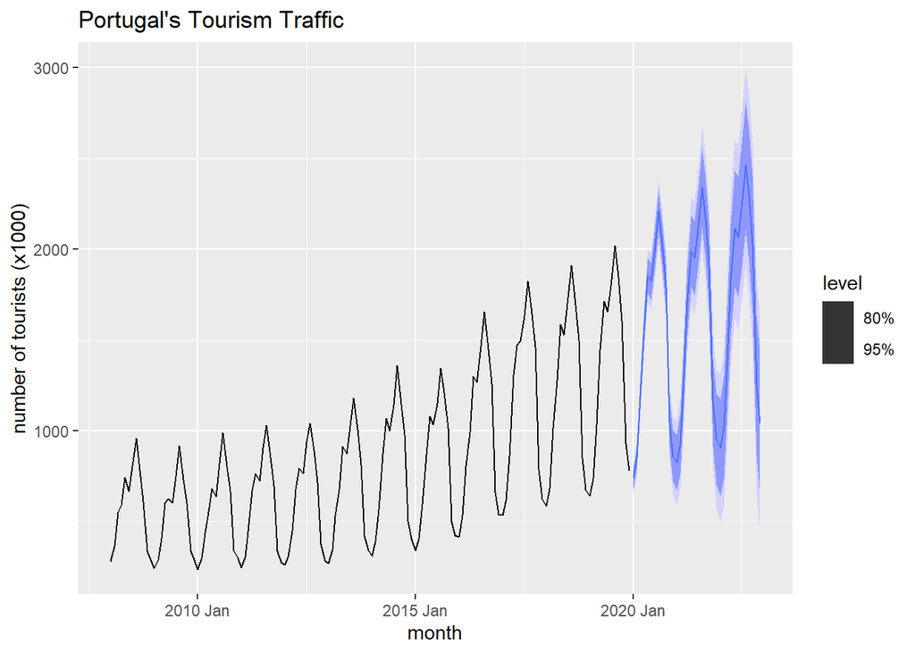

```r
forecast(pt_fit, h=36) %>%
filter(.model=='sarima110_112') %>%
autoplot(pt_tour) +
labs(title = "Portugal's Tourism Traffic",
y="number of tourists (x1000)")
```

### Validating the accuracy of the selected model

After forecasting the series based on the model, it is imperative to validate the model’s accuracy. We need to test how well each model can predict data it has not seen. To do this, we split the series into a training set (all observations up to 2018) and a test set (2019 only). Each candidate model is estimated using only the training data, so it “learns” patterns such as trend, seasonality, and short-term dependence without looking at 2019. We then generate forecasts for 2019 and compare those forecasts to the actual observed values in 2019. This is called out-of-sample evaluation, and it’s more honest than just checking in-sample fit, because it tests true predictive performance. After producing the forecasts, we can both visually inspect how close the forecast lines are to the real 2019 values, and compute accuracy metrics (ME, RMSE, MAE, MPE, MAPE, MASE, RMSSE, ACF1) to quantify forecast error. The model with the lowest forecast error on the 2019 test set is the model we’ll consider most reliable for future forecasting.

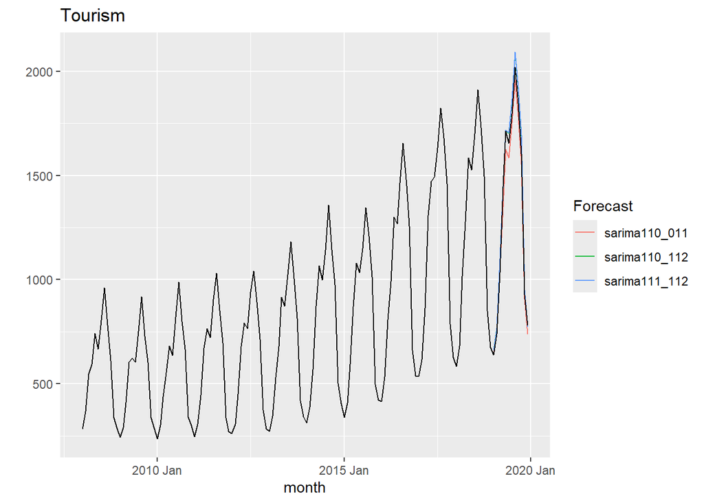

```r
#Training data
pt_train <- pt_tour %>%
  filter(year(month) < 2019)
#Test data
pt_test <- pt_tour %>%
  filter(year(month) >= 2019, year(month) <= 2019)
#Fit models in training data
pt_fit <- pt_train %>%
  model(
    sarima111_112 = ARIMA(tourist ~ pdq(1,1,1) + PDQ(1,1,2)),
    sarima110_112 = ARIMA(tourist ~ pdq(1,1,0) + PDQ(1,1,2)),
    sarima110_011 = ARIMA(tourist ~ pdq(1,1,0) + PDQ(0,1,1)),
  )
#Forecast in test data
pt_fc <- pt_fit %>%
  forecast(pt_test)
#Plot results
pt_fc %>%
  autoplot(bind_rows(pt_train, pt_test), level = NULL) +
  labs(y = '', title = 'Tourism') +
  guides(colour = guide_legend(title = "Forecast"))
```

```r
#Comparing the model's accuracy
fabletools::accuracy(pt_fc, dplyr::bind_rows(pt_train, pt_test))
```

| .model | .type | ME | RMSE | MAE | MPE | MAPE | MASE | RMSSE | ACF1 |
| --- | --- | --- | --- | --- | --- | --- | --- | --- | --- |
| sarima110_011 | Test | 41.70659 | 55.53013 | 47.51209 | 2.626141 | 3.307540 | 0.5990129 | 0.5152408 | 0.3640582 |
| sarima110_112 | Test | -39.19940 | 50.05369 | 41.21855 | -2.857236 | 3.057246 | 0.5196665 | 0.4644272 | 0.3085388 |
| sarima111_112 | Test | -40.92369 | 52.28936 | 42.64862 | -2.927000 | 3.111768 | 0.5376962 | 0.4851710 | 0.3325825 |

### Accuracy Report and Conclusion

To justify the model selection, the SARIMA(1,1,0)(1,1,2)[12] model was selected as the final forecasting model based on its strong out-of-sample performance and adherence to the Box–Jenkins principles. It yielded the lowest overall forecast errors (RMSE = 50.05, MAE = 41.22, MAPE = 3.06%) and produced residuals that are approximately white noise, with no significant autocorrelation (ACF₁ = 0.31). Following the Box–Jenkins criterion of selecting the most parsimonious and statistically adequate model, SARIMA(1,1,0)(1,1,2)[12] provides the best balance between model simplicity, goodness of fit, and forecasting accuracy for Portugal’s tourism demand series.

*Future improvements* could involve incorporating external regressors such as international flight arrivals or macroeconomic indicators.

Eurostat. n.d. “Arrivals at Tourist Accommodation Establishments - Monthly Data — Portugal.” Luxembourg: Statistical Office of the European Union. https://ec.europa.eu/eurostat.

Hyndman, Rob J., and George Athanasopoulos. n.d. *Forecasting: Principles and Practice (3rd Ed.)*. OTexts. https://otexts.com/fpp3/.

Hyndman, Rob J., Mitchell O’Hara-Wild, and Earo Wang. n.d. “Feasts: Feature Extraction and Statistics for Time Series.” https://feasts.tidyverts.org/.

OECD. 2025. “Guidance to Develop a Tourism Demand Forecasting Model for Portugal.” *OECD Tourism Papers*. 2025/10. Paris: OECD Publishing. https://doi.org/10.1787/8a941e5e-en.

Pfaff, Bernhard. n.d. “Urca: Unit Root and Cointegration Tests for Time Series Data.” https://cran.r-project.org/package=urca.

R Core Team. n.d. “R: A Language and Environment for Statistical Computing.” Vienna, Austria: R Foundation for Statistical Computing. https://www.r-project.org/.

Tang, Yixuan. n.d. “Prettydoc: Creating Pretty Documents from R Markdown.” https://cran.r-project.org/package=prettydoc.

Wang, Earo, Dianne Cook, and Rob J. Hyndman. n.d. “Tsibble: Tidy Temporal Data Frames and Tools.” https://tsibble.tidyverts.org/.

Wickham, Hadley, Jim Hester, and Jennifer Bryan. n.d. “Readr: Read Rectangular Text Data.” https://readr.tidyverse.org/.

Zhu, Hao. n.d. “kableExtra: Construct Complex Table with ‘Kable’ and Pipe Syntax.” https://haozhu233.github.io/kableExtra/.